# Pan-African tectonism and major structural elements

Dr. Ahmad Redaa

2026-04-12

# Introduction

Pan-African tectonism represents a major Neoproterozoic orogenic system responsible for the formation of large portions of the crust in Africa and Arabia, including the Arabian Shield. This lecture introduces key concepts, tectonic evolution, and structural elements associated with this orogenic cycle.

# What is an Orogeny?

An **orogeny** is a tectonic process involving mountain building, typically associated with:

- Plate convergence
- Subduction and/or continental collision
- Crustal shortening and thickening

## Key features:

- Folding and thrusting
- Development of shear zones and faults
- Regional metamorphism
- Magmatism

# The Pan-African Orogeny

The **Pan-African orogeny** refers to a series of Neoproterozoic tectonic events affecting Africa and Arabia.

## Timeframe:

- ~900 to 550 Ma

## Significance:

- Formation of the Arabian-Nubian Shield
- Assembly of Gondwana

# Pan-African vs East African Orogeny

## Pan-African Orogeny:

- Broad, global-scale tectonic system
- Includes multiple orogenic belts

## East African Orogen:

- A specific collisional belt within the Pan-African system
- Represents collision between East and West Gondwana

# Relationship to the Arabian Shield

The Arabian Shield formed as part of the Arabian-Nubian Shield during Pan-African tectonism.

## Key characteristics:

- Dominated by juvenile arc systems
- Developed above subduction zones in the Mozambique Ocean

Oceanic crust remnants are preserved as ophiolites along sutures between terranes

# Timing of Tectonic Events

## Early Stage (~900–800 Ma)

- Formation of island arcs

## Arc Accretion (~800–700 Ma)

- Arc–arc collisions
- Formation of ophiolitic sutures

## Terminal Collision (~650–550 Ma)

- Closure of ocean basins
- Development of major shear zones

# Major Structural Elements

## 1. Suture Zones

- Boundaries between terranes
- Mark sites of former ocean basins
- Often contain ophiolites

## 2. Shear Zones and Faults

- Accommodate large-scale deformation
- Range from brittle faults to ductile shear zones

Deformation includes folding, faulting, and shearing

# Structural Styles in the Arabian Shield

## Deformation Types:

- Compression → folding
- Translation → faulting, shearing and thrusting
- Extension → jointing

Rocks exhibit:  
- Tight to open folds  
- Fault zones up to hundreds of kilometers long  
- Regional metamorphism from greenschist to amphibolite facies

# Terranes

Terranes are distinct crustal blocks with unique geological histories.

In the Arabian Shield:  
- Island arc terranes dominate  
- Accreted during Pan-African convergence

# Major Structural Elements of the Arabian Shield

The Arabian Shield exhibits a complex structural architecture formed during the Pan-African orogeny. These structures record multiple phases of deformation associated with terrane accretion, collision, and post-collisional tectonics.

# Overview of Structural Framework

All Precambrian rocks in the Arabian Shield are deformed to varying degrees.

## Key observations:

- Widespread folding, faulting, and shearing
- Regional metamorphism (greenschist → amphibolite facies)
- Multiple deformation phases

Deformation includes compression (folding), translation (faulting and shearing), and extension (jointing)

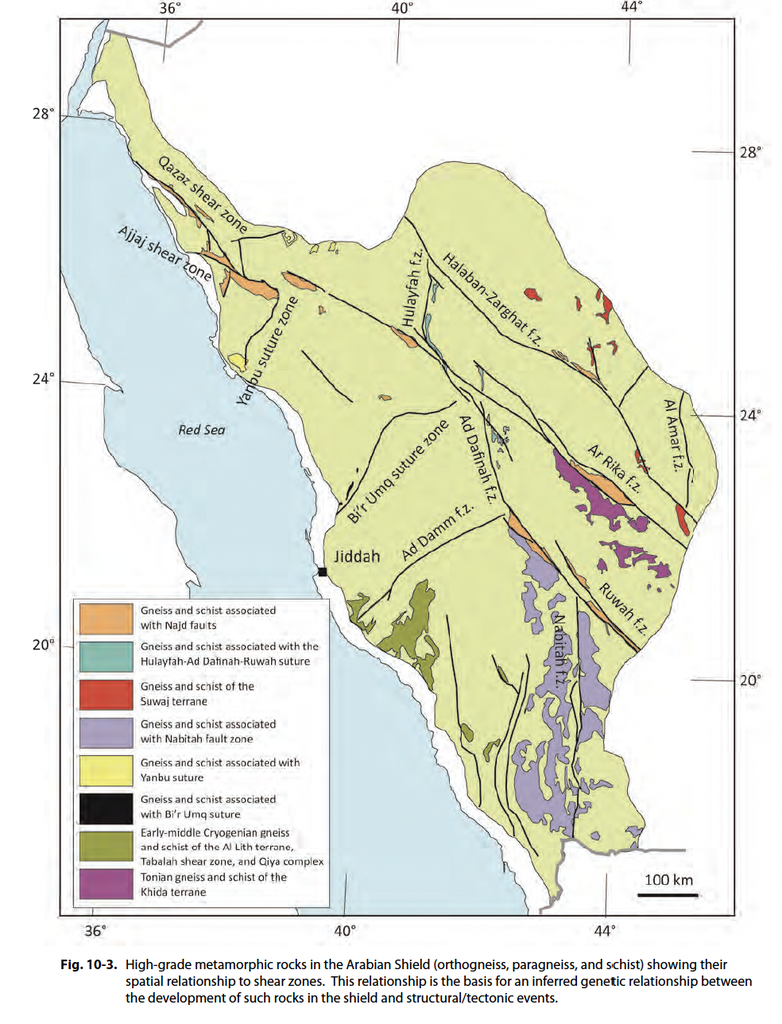

Source: Johnson PR, Kattan FH (2012) The geology of the Saudi Arabian shield: Saudi geological survey: Jeddah, Saudi Arabia, pp 1–479

# Suture Zones

## Definition:

Suture zones are tectonic boundaries marking the closure of ocean basins and the collision of terranes.

## Characteristics:

- Presence of ophiolites
- High-strain deformation zones
- Mélange and disrupted lithologies

## Importance:

- Record arc–arc and arc–continent collisions
- Indicate locations of former oceanic crust

## Examples in the Arabian Shield:

- Bi’r Umq suture
- Nabitah suture
- Halaban suture

Ophiolites are commonly preserved along these sutures and represent fragments of oceanic crust emplaced during convergence

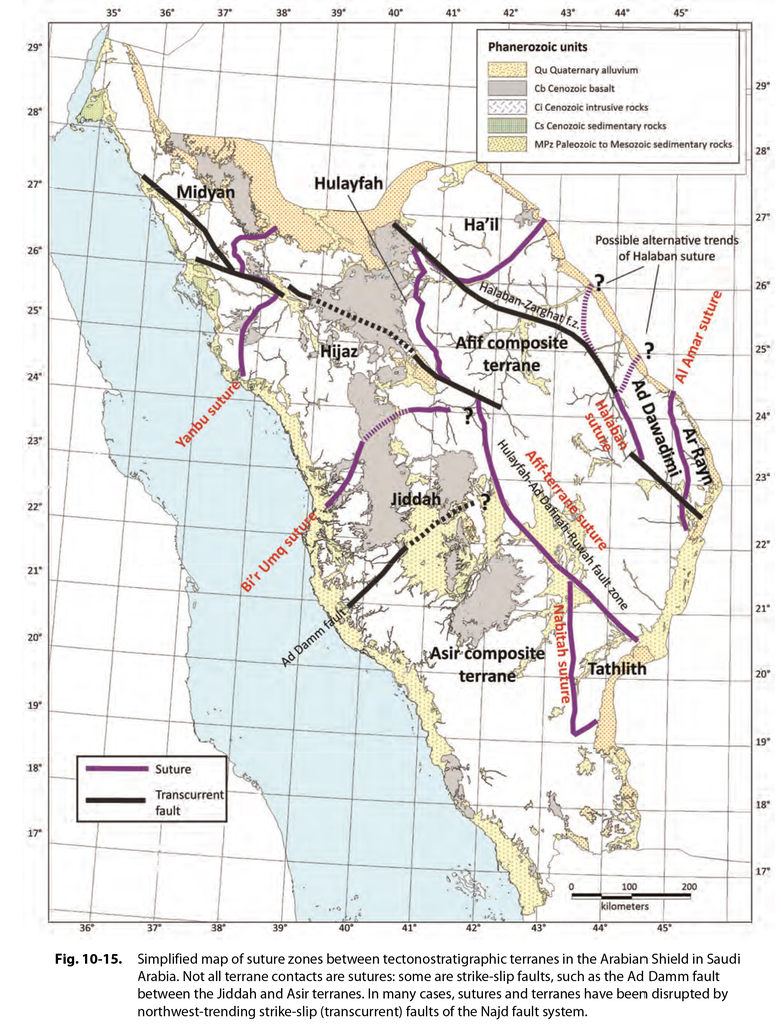

Source: Johnson PR, Kattan FH (2012) The geology of the Saudi Arabian shield: Saudi geological survey: Jeddah, Saudi Arabia, pp 1–479

# Shear Zones

## Definition:

Shear zones are tabular zones of intense deformation accommodating displacement between crustal blocks.

## Types:

- Brittle shear zones → faults
- Ductile shear zones → mylonitic belts

## Characteristics:

- Width: centimeters to kilometers
- Length: up to hundreds of kilometers
- Contain mylonites, schists, and gneisses

Shear zones may represent:  
- Sutures between terranes  
- Later reactivated structures  
- Strike-slip fault systems

# Major Shear Systems

## Tabalah–Tarj Shear Zone

- Strike-slip shear system in southern shield
- Shows evidence of dextral deformation
- Associated with arc-related plutons

# Fault Systems

## Definition:

Faults are brittle fractures along which displacement has occurred.

## Types in the Arabian Shield:

- Normal faults → extensional regimes
- Reverse/thrust faults → compressional regimes
- Strike-slip faults → lateral displacement

## Characteristics:

- Range from meters to hundreds of kilometers
- Often reactivated multiple times

Fault zones are fundamental to the structural architecture and may control mineralization

## Najd Fault System

- Large-scale NW–SE trending strike-slip faults
- Developed during late Pan-African tectonics
- Associated with continental escape tectonics

## Nabitah Fault Zone

- Major crustal-scale shear zone
- Marks terrane boundaries
- Associated with high-grade metamorphism

# Folding

## Types of folds:

- Open folds → large wavelength
- Tight to isoclinal folds → high strain

## Features:

- Associated with compressional tectonics
- May include cleavage development
- Occur at scales from centimeters to kilometers

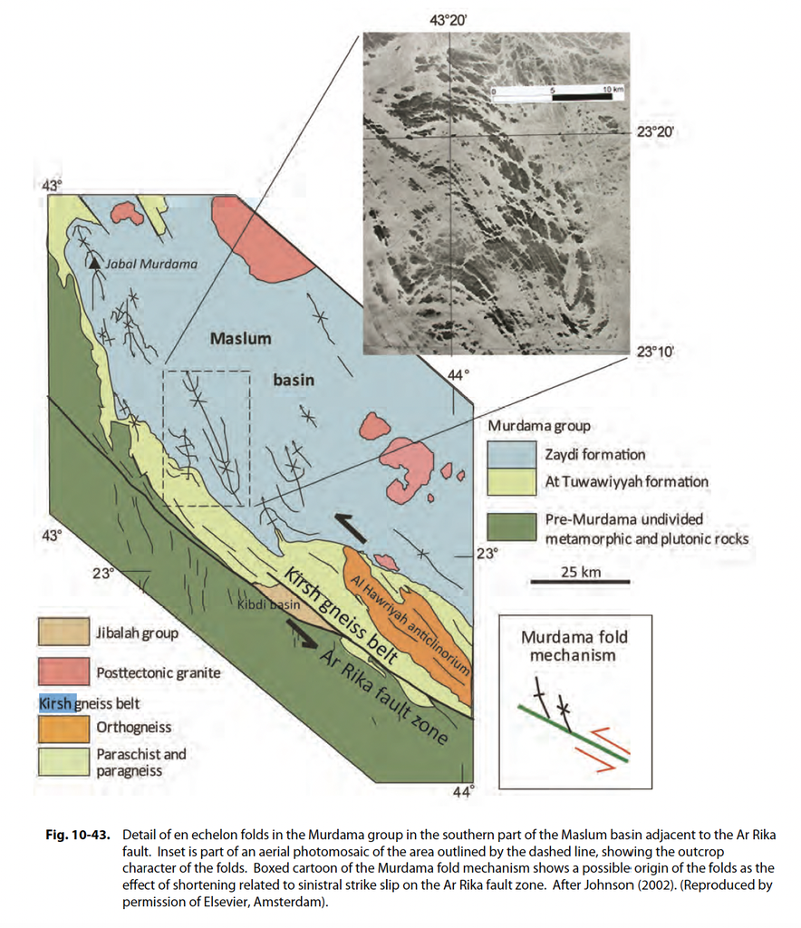

Source: Johnson PR, Kattan FH (2012) The geology of the Saudi Arabian shield: Saudi geological survey: Jeddah, Saudi Arabia, pp 1–479

# Structural Trends and Orientation

## Regional patterns:

- Southern shield → N–S trending structures
- Northern shield → NW and NE trends
- Coastal regions → NE trends

These trends reflect different tectonic regimes during and after terrane amalgamation

# Economic and Geological Importance

Structural elements control:

- Mineralization (e.g., gold in shear zones)
- Fluid flow and hydrothermal systems
- Localization of ore deposits

Shear zones are particularly important as metallotects (ore-controlling structures)

# Summary of Major Structures

| Structure Type | Key Features | Tectonic Significance |
| --- | --- | --- |
| Suture zones | Ophiolites, mélanges | Ocean closure, collision |
| Shear zones | High-strain deformation | Terrane boundaries, reactivation |
| Faults | Brittle displacement | Crustal movement |
| Folds | Compressional structures | Crustal shortening |
| Terranes | Distinct crustal blocks | Arc accretion |